# Ejercicio extendido - ACP incluyendo los metadatos de precisión

# Fase 4 — El ACP extendido

Se excluyen primero las dos columnas de varianza cero y se imputa el resto con `missMDA` (nunca con la imputación por media que ofrece FactoMineR por defecto).

```r
ext <- acp_extendido(mat71, ncp_imp = 5, ncp = 10)

tibble(
  concepto = c("Variables excluidas por varianza cero",
               "Variables en el ACP", "Componentes de imputación (ncp)",
               "Celdas imputadas"),
  valor = c(paste(ext$excluidas_varianza, collapse = ", "),
            ncol(ext$imputacion$X), ext$imputacion$ncp,
            paste0(ext$imputacion$pct_imputado, "%"))
) %>%
  kable(caption = "Configuración del ACP extendido") %>%
  kable_styling(bootstrap_options = c("striped", "hover"))
```

Configuración del ACP extendido

| concepto | valor |
| --- | --- |
| Variables excluidas por varianza cero | pl_insollim, st_radlim |
| Variables en el ACP | 69 |
| Componentes de imputación (ncp) | 5 |
| Celdas imputadas | 29.6% |

## Eigenvalores del ACP extendido

```r
resumen_ejes(ext$resultado, 8) %>%
  kable(caption = "Eigenvalores del ACP con 69 variables", digits = c(0, 3, 2, 2)) %>%
  kable_styling(bootstrap_options = c("striped", "hover", "condensed"))
```

Eigenvalores del ACP con 69 variables

| eje | eigenvalor | pct_var | pct_acum |
| --- | --- | --- | --- |
| 1 | 17.784 | 25.77 | 25.77 |
| 2 | 12.075 | 17.50 | 43.27 |
| 3 | 7.330 | 10.62 | 53.90 |
| 4 | 5.357 | 7.76 | 61.66 |
| 5 | 3.465 | 5.02 | 66.68 |
| 6 | 1.646 | 2.38 | 69.07 |
| 7 | 1.459 | 2.12 | 71.18 |
| 8 | 1.310 | 1.90 | 73.08 |

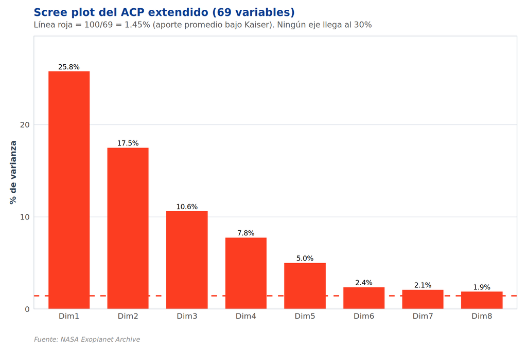

Scree plot del ACP extendido: la varianza se reparte en muchos ejes

```r
tibble(
  eje = paste0("Dim", 1:8),
  pct = resumen_ejes(ext$resultado, 8)$pct_var
) %>%
  ggplot(aes(x = eje, y = pct, fill = pct >= 100 / 69)) +
  geom_col(width = 0.7) +
  geom_text(aes(label = sprintf("%.1f%%", pct)), vjust = -0.4, size = 3) +
  geom_hline(yintercept = 100 / 69, linetype = "dashed",
             color = nasa_col("secondary"), linewidth = 0.8) +
  scale_fill_nasa(niveles = c(FALSE, TRUE), labels = c("< 100/69", "≥ 100/69"),
                  guide = "none") +
  scale_y_continuous(expand = expansion(mult = c(0, 0.15))) +
  labs(title = "Scree plot del ACP extendido (69 variables)",
       subtitle = sprintf("Línea roja = 100/69 = %.2f%% (aporte promedio bajo Kaiser). Ningún eje llega al 30%%",
                          100 / 69),
       x = "", y = "% de varianza", caption = "Fuente: NASA Exoplanet Archive") +
  theme_nasa()
```

# Fase 5 — Comparación con el ACP de 16 variables

Para comparar, corremos también el ACP principal sobre las mismas 6.207 filas:

```r
sel <- seleccionar_variables_acp(raw_data, restringir_por_masa = TRUE)
sup_cuali <- raw_data %>%
  filter(!is.na(pl_bmasse), pl_bmasse != "") %>%
  transmute(discoverymethod = factor(discoverymethod), soltype = factor(soltype))
imp_limpio <- imputar_acp(sel$matriz)
res_limpio <- correr_acp(imp_limpio$X, ncp = 5, quali_sup = sup_cuali)
```

## 5.1 La varianza se diluye

```r
comparar_eigenvalores(ext$resultado, res_limpio, "extendido_69", "contenido_16", n = 5) %>%
  kable(caption = "% de varianza explicada por eje: ACP extendido vs ACP de contenido",
        digits = c(0, 2, 2, 2, 2)) %>%
  kable_styling(bootstrap_options = c("striped", "hover"))
```

% de varianza explicada por eje: ACP extendido vs ACP de contenido

| eje | extendido_69 | contenido_16 | acum_a | acum_b |
| --- | --- | --- | --- | --- |
| Dim1 | 25.77 | 36.56 | 25.77 | 36.56 |
| Dim2 | 17.50 | 28.96 | 43.27 | 65.52 |
| Dim3 | 10.62 | 8.32 | 53.89 | 73.84 |
| Dim4 | 7.76 | 6.54 | 61.65 | 80.38 |
| Dim5 | 5.02 | 4.48 | 66.67 | 84.86 |

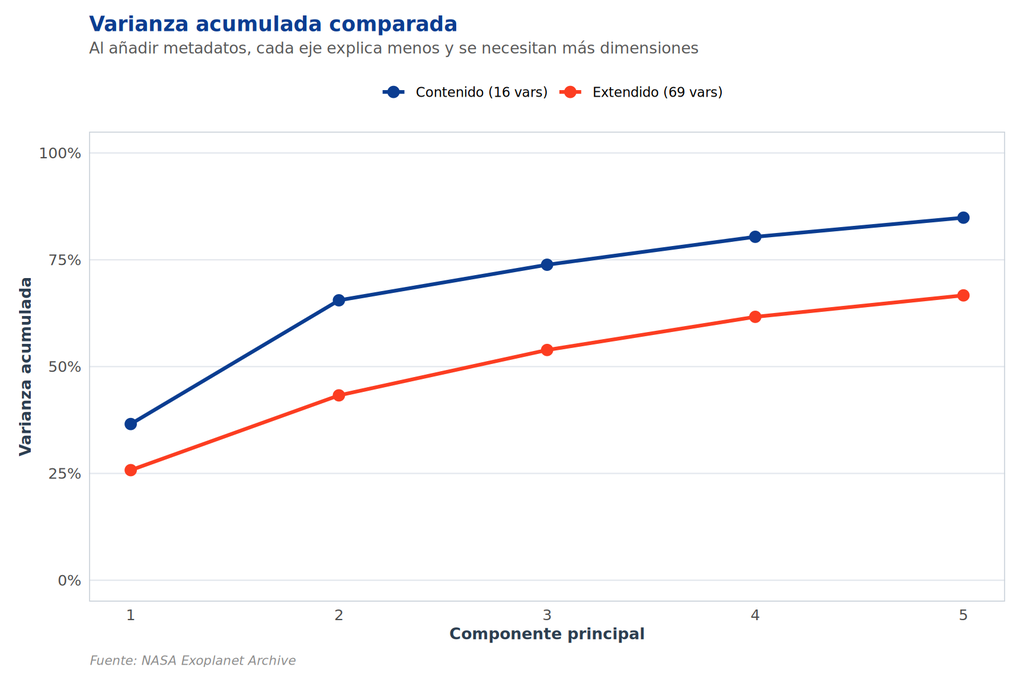

Varianza acumulada: con 69 variables hace falta mucho más dimensionalidad

```r
bind_rows(
  tibble(eje = 1:5, acum = cumsum(resumen_ejes(ext$resultado, 5)$pct_var),
         conjunto = "Extendido (69 vars)"),
  tibble(eje = 1:5, acum = cumsum(resumen_ejes(res_limpio, 5)$pct_var),
         conjunto = "Contenido (16 vars)")
) %>%
  ggplot(aes(x = eje, y = acum, color = conjunto, group = conjunto)) +
  geom_line(linewidth = 1.1) + geom_point(size = 3) +
  scale_color_nasa(n = 2) +
  scale_x_continuous(breaks = 1:5) +
  scale_y_continuous(labels = function(x) paste0(x, "%"), limits = c(0, 100)) +
  labs(title = "Varianza acumulada comparada",
       subtitle = "Al añadir metadatos, cada eje explica menos y se necesitan más dimensiones",
       x = "Componente principal", y = "Varianza acumulada", color = "",
       caption = "Fuente: NASA Exoplanet Archive") +
  theme_nasa()
```

**Lectura:** el ACP de 16 variables alcanza el **80,4%** en 4 componentes; el extendido apenas llega al **61,7%** en 4 y al 66,7% en 5. Añadir 53 columnas al ACP de contenido **diluye** la varianza sin aportar estructura nueva interpretable.